# Data Exploration for Census Socio-economic Dataset

## 2.4 Inspect High-level-count Categorical Variables

With the raw data loaded up we now remove obvious unique or near-unique variables that are not amenable to basic exploration and plotting.

```r
coltype_lst <- create_coltype_list(data_tbl)

if(!is.null(coltype_lst$split$discrete)) {
    catvar_valuecount_tbl <- data_tbl %>%
        summarise_at(coltype_lst$split$discrete
                    ,function(x) length(unique(x))) %>%
        gather('var_name', 'level_count') %>%
        arrange(-level_count)

    print(catvar_valuecount_tbl)

    row_count <- nrow(data_tbl)

    cat(paste0("Dataset has ", row_count, " rows\n"))
} else {
    cat('No categorical variables in dataset\n')
}
```

```
## # A tibble: 9 x 2
##   var_name       level_count
##   <chr>                <int>
## 1 native_country          42
## 2 education               16
## 3 occupation              15
## 4 workclass                9
## 5 marital_status           7
## 6 relationship             6
## 7 race                     5
## 8 sex                      2
## 9 salary_band              2
## Dataset has 32561 rows
```

Now that we a table of the counts of all the categorical variables we can automatically exclude unique variables from the exploration, as the level count will match the row count.

```r
if(!is.null(coltype_lst$split$discrete)) {
    unique_vars <- catvar_valuecount_tbl %>%
        filter(level_count == row_count) %>%
        .[["var_name"]]

    print(unique_vars)

    explore_data_tbl <- data_tbl %>%
        dplyr::select(-one_of(unique_vars))
} else {
    explore_data_tbl <- data_tbl
}
```

```
## character(0)
```

Having removed the unique identifier variables from the dataset, we may also wish to exclude categoricals with high level counts also, so we create a vector of those variable names.

```r
if(!is.null(coltype_lst$split$discrete)) {
    highcount_vars <- catvar_valuecount_tbl %>%
        filter(level_count >= dataexp_level_exclusion_threshold
              ,level_count < row_count) %>%
        .[["var_name"]]

    cat(paste0(highcount_vars, collapse = ', '))
} else {
    highcount_vars <- c()
}
```

We now can continue doing some basic exploration of the data. We may also choose to remove some extra columns from the dataset.

```r
### You may want to comment out these next few lines to customise which
### categoricals are kept in the exploration.
drop_vars <- c(highcount_vars)

if(length(drop_vars) > 0) {
    explore_data_tbl <- explore_data_tbl %>%
        dplyr::select(-one_of(drop_vars))

    cat(paste0(drop_vars, collapse = ', '))
}
```

## 2.5 Write Loaded Data to Disk

```r
#data_tbl %>% write_csv(path = 'data/loaded_data.csv')
```

# 3 Univariate Data Exploration

Now that we have loaded the data we can prepare it for some basic data exploration. We first exclude the variables that are unique identifiers or similar, and tehen split the remaining variables out into various categories to help with the systematic data exploration.

```r
coltype_lst <- create_coltype_list(explore_data_tbl)

print(coltype_lst)
```

```
## $split
## $split$continuous
## [1] "age"            "fnlwght"        "education_num"  "capital_gain"   "capital_loss"
## [6] "hours_per_week"
##
## $split$discrete
## [1] "workclass"      "education"      "marital_status" "occupation"     "relationship"
## [6] "race"           "sex"            "native_country" "salary_band"
##
##
## $columns
##            age      workclass        fnlwght      education  education_num marital_status
##   "continuous"     "discrete"   "continuous"     "discrete"   "continuous"     "discrete"
##     occupation   relationship           race            sex   capital_gain   capital_loss
##     "discrete"     "discrete"     "discrete"     "discrete"   "continuous"   "continuous"
## hours_per_week native_country    salary_band
##   "continuous"     "discrete"     "discrete"
```

## 3.1 Logical Variables

Logical variables only take two values: TRUE or FALSE. It is useful to see missing data as well though, so we also plot the count of those.

```r
logical_vars <- coltype_lst$split$logical

for(plot_varname in logical_vars) {
    cat("--\n")
    cat(paste0(plot_varname, '\n'))

    na_count <- explore_data_tbl %>% .[[plot_varname]] %>% is.na %>% sum

    explore_plot <- ggplot(explore_data_tbl) +
        geom_bar(aes_string(x = plot_varname)) +
        xlab(plot_varname) +
        ylab("Count") +
        scale_y_continuous(labels = comma) +
        ggtitle(paste0('Barplot of Counts for Variable: ', plot_varname
                      ,' (', na_count, ' missing values)')) +
        theme(axis.text.x = element_text(angle = 90, vjust = 0.5))

    plot(explore_plot)
}
```

## 3.2 Numeric Variables

Numeric variables are usually continuous in nature, though we also have integer data.

```
## --
## age
##    Min. 1st Qu.  Median    Mean 3rd Qu.    Max.
##    17.0    28.0    37.0    38.6    48.0    90.0
```

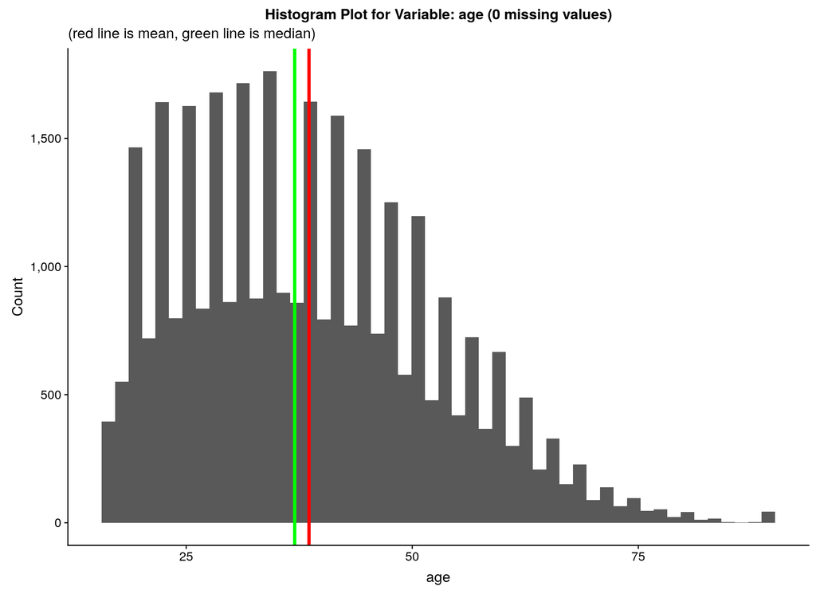

```
## --
## fnlwght
##    Min. 1st Qu.  Median    Mean 3rd Qu.    Max.
##   12285  117827  178356  189778  237051 1484705
```

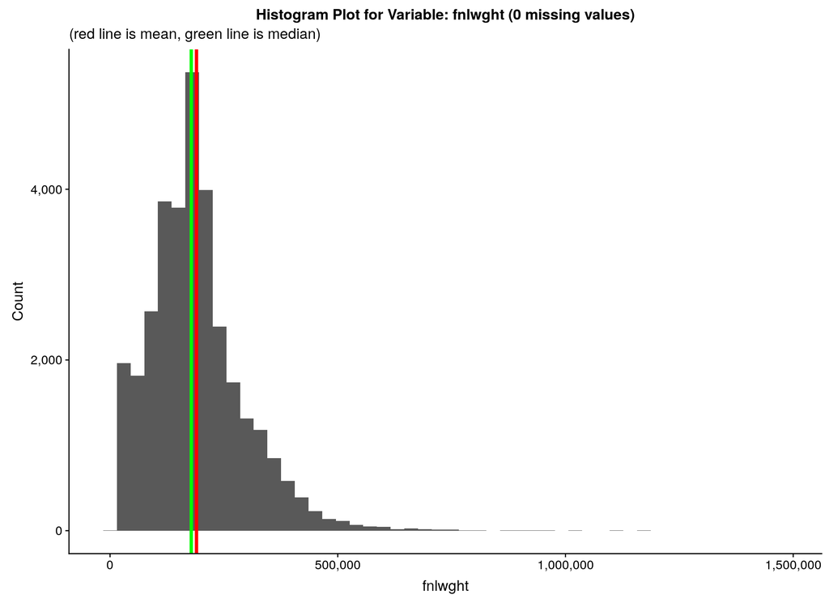

```
## --
## education_num
##    Min. 1st Qu.  Median    Mean 3rd Qu.    Max.
##     1.0     9.0    10.0    10.1    12.0    16.0
```

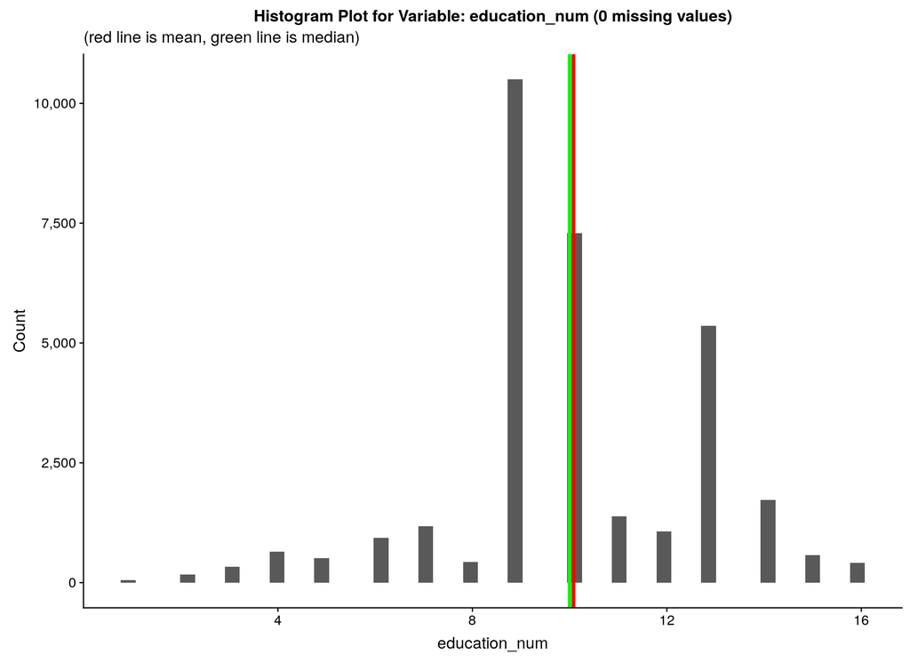

```
## --
## capital_gain
##    Min. 1st Qu.  Median    Mean 3rd Qu.    Max.
##       0       0       0    1078       0   99999
```

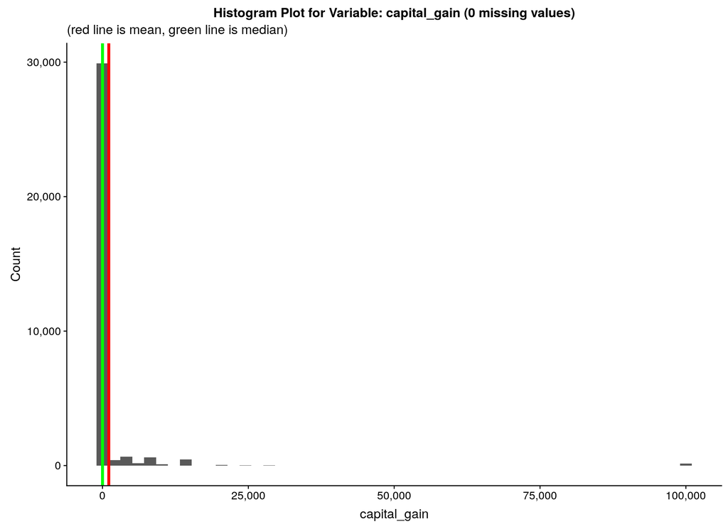

```
## --
## capital_loss
##    Min. 1st Qu.  Median    Mean 3rd Qu.    Max.
##     0.0     0.0     0.0    87.3     0.0  4356.0
```

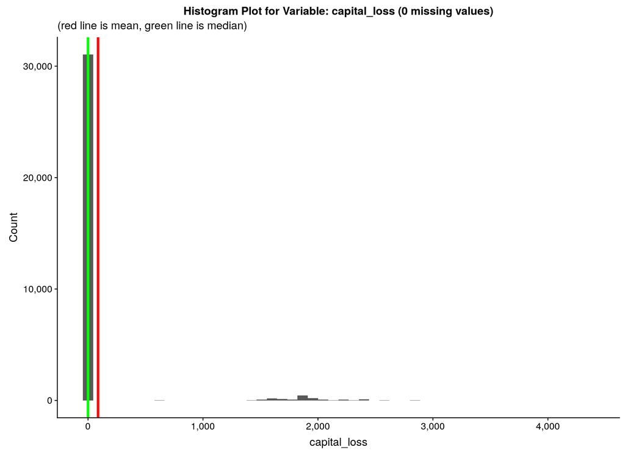

```
## --
## hours_per_week
##    Min. 1st Qu.  Median    Mean 3rd Qu.    Max.
##     1.0    40.0    40.0    40.4    45.0    99.0
```

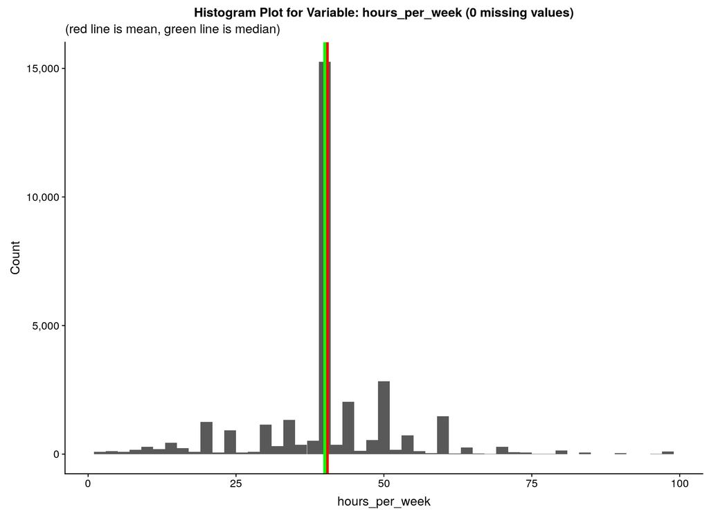

```r
numeric_vars <- coltype_lst$split$continuous

for(plot_varname in numeric_vars) {
    cat("--\n")
    cat(paste0(plot_varname, '\n'))

    plot_var <- explore_data_tbl %>% .[[plot_varname]]
    na_count <- plot_var %>% is.na %>% sum

    plot_var %>% summary %>% print

    explore_plot <- ggplot(explore_data_tbl) +
        geom_histogram(aes_string(x = plot_varname), bins = dataexp_hist_bins_count) +
        geom_vline(xintercept = mean  (plot_var, na.rm = TRUE), colour = 'red',   size = 1.5) +
        geom_vline(xintercept = median(plot_var, na.rm = TRUE), colour = 'green', size = 1.5) +
        xlab(plot_varname) +
        ylab("Count") +
        scale_x_continuous(labels = comma) +
        scale_y_continuous(labels = comma) +
        ggtitle(paste0('Histogram Plot for Variable: ', plot_varname
                      ,' (', na_count, ' missing values)')
               ,subtitle = '(red line is mean, green line is median)')

    print(explore_plot)
}
```

## 3.3 Categorical Variables

Categorical variables only have values from a limited, and usually fixed, number of possible values

```
## --
## workclass
```

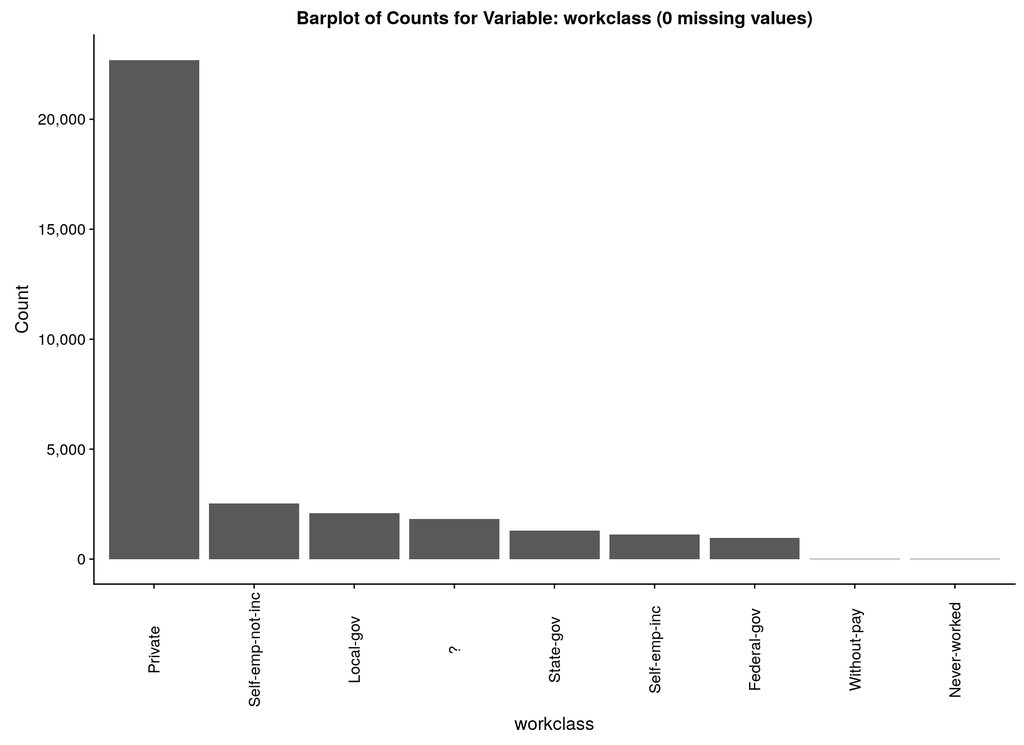

```
## --
## education
```

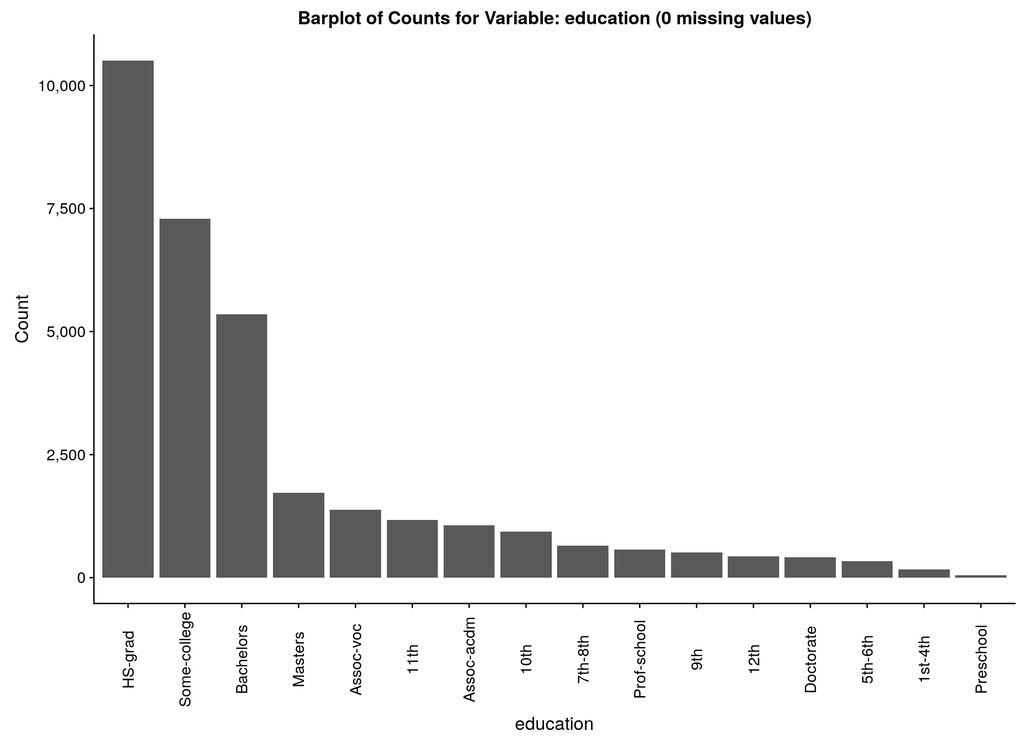

```
## --
## marital_status
```

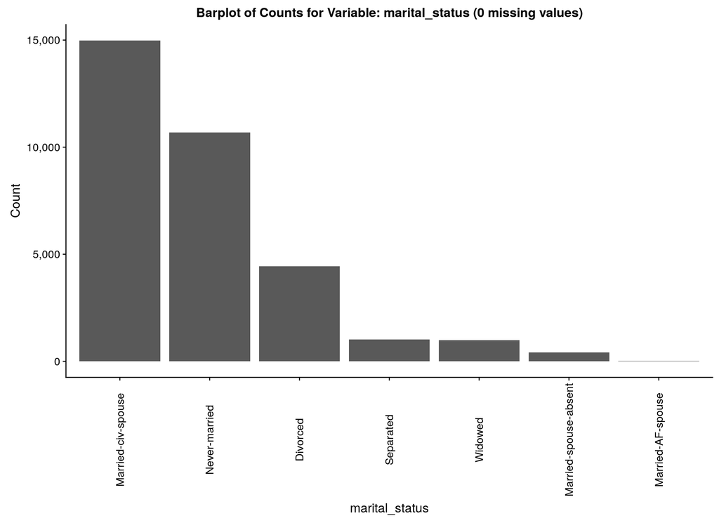

```
## --
## occupation
```

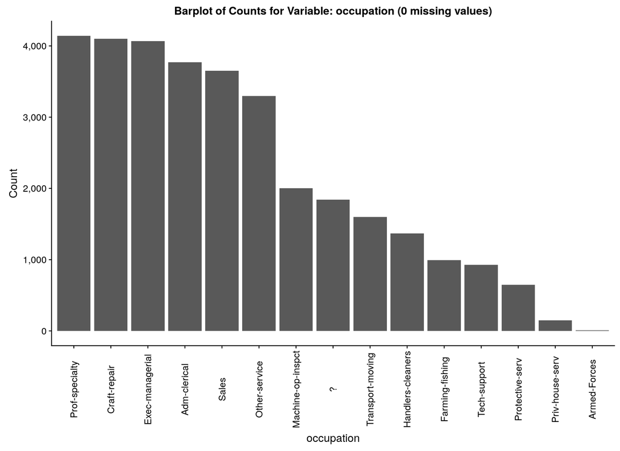

```
## --
## relationship
```

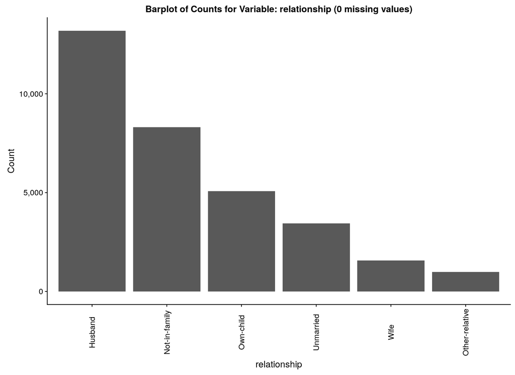

```
## --
## race
```

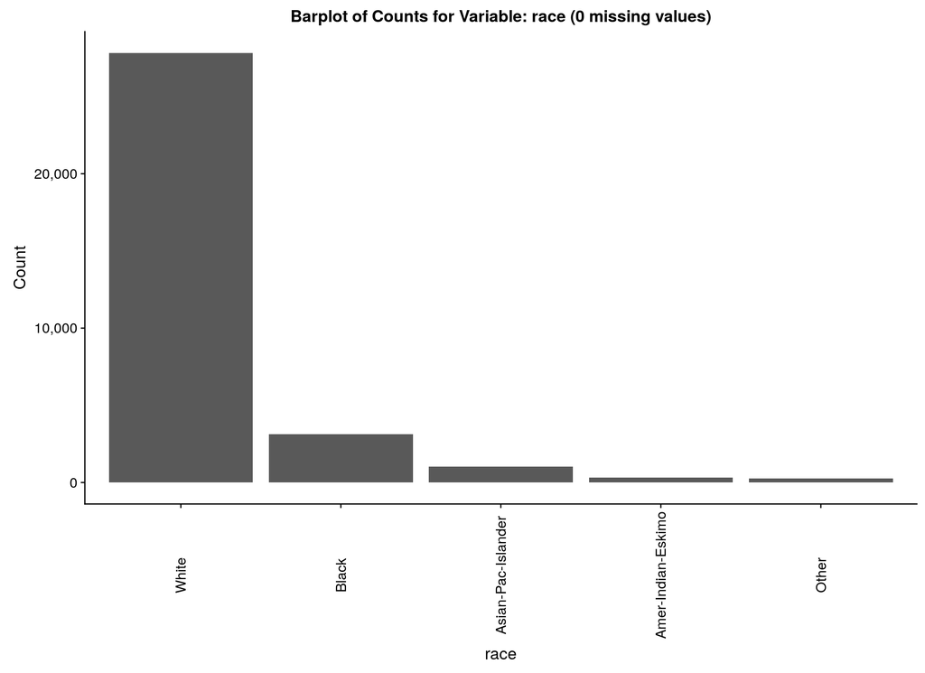

```
## --
## sex
```

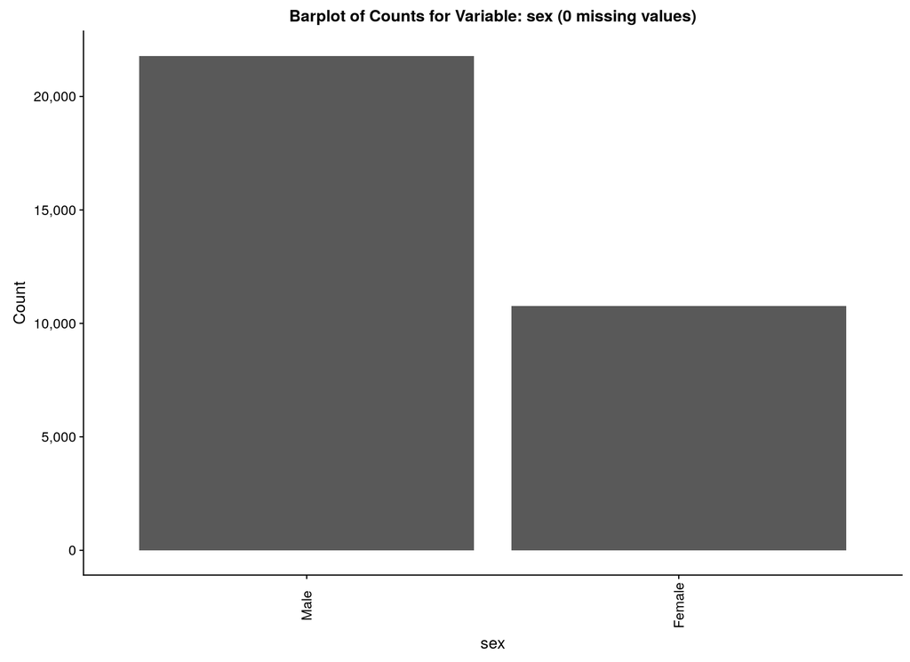

```
## --
## native_country
```

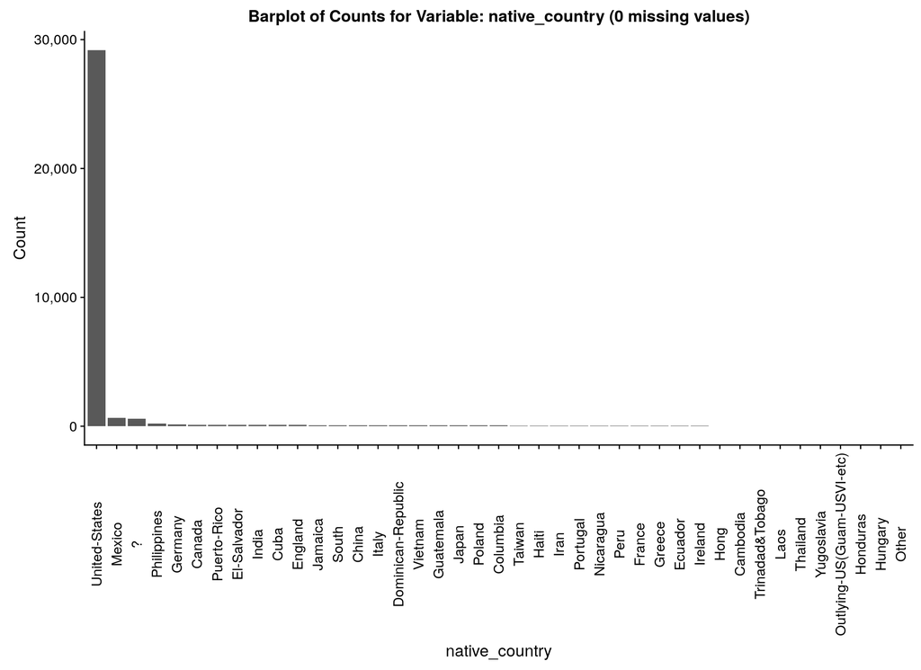

```
## --
## salary_band
```

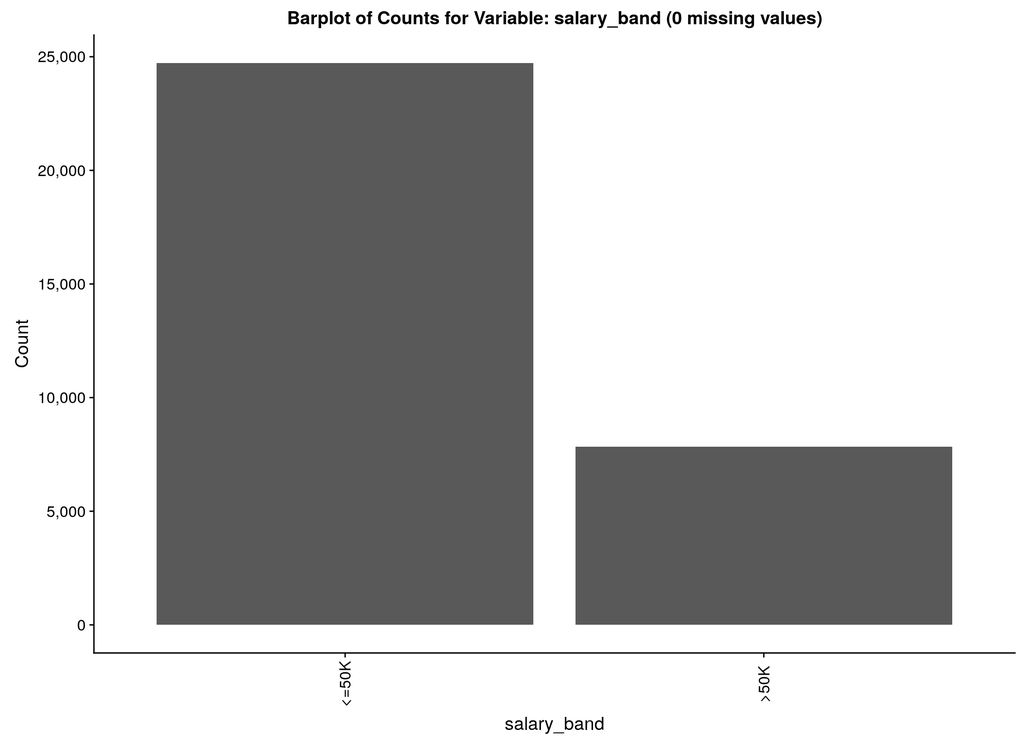

```r
categorical_vars <- coltype_lst$split$discrete

for(plot_varname in categorical_vars) {
    cat("--\n")
    cat(paste0(plot_varname, '\n'))

    na_count <- explore_data_tbl %>% .[[plot_varname]] %>% is.na %>% sum

    plot_tbl <- explore_data_tbl %>%
        .[[plot_varname]] %>%
        as.character %>%
        fct_lump(n = dataexp_cat_level_count) %>%
        fct_count

    explore_plot <- ggplot(plot_tbl) +
        geom_bar(aes(x = fct_reorder(f, -n), weight = n)) +
        xlab(plot_varname) +
        ylab("Count") +
        scale_y_continuous(labels = comma) +
        ggtitle(paste0('Barplot of Counts for Variable: ', plot_varname
                      ,' (', na_count, ' missing values)')) +
        theme(axis.text.x = element_text(angle = 90, vjust = 0.5))

    plot(explore_plot)
}
```

## 3.4 Date/Time Variables

Date/Time variables represent calendar or time-based data should as time of the day, a date, or a timestamp.

```r
datetime_vars <- coltype_lst$split$datetime

for(plot_varname in datetime_vars) {
    cat("--\n")
    cat(paste0(plot_varname, '\n'))

    plot_var <- explore_data_tbl %>% .[[plot_varname]]
    na_count <- plot_var %>% is.na %>% sum

    plot_var %>% summary %>% print

    explore_plot <- ggplot(explore_data_tbl) +
        geom_histogram(aes_string(x = plot_varname), bins = dataexp_hist_bins_count) +
        xlab(plot_varname) +
        ylab("Count") +
        scale_y_continuous(labels = comma) +
        ggtitle(paste0('Barplot of Dates/Times in Variable: ', plot_varname
                      ,' (', na_count, ' missing values)'))

    plot(explore_plot)
}
```